# Spotify-Predicting songs’ popularity with linear regression

Gabriele Fulcheri

2022-10-20

## Introduction

Is it possible to predict the popularity of a song? Which are the features of it that may have the biggest impact on its popularity?

Analyzing the Kaggle’s dataset [Top Hits Spotify from 2000-2019](https://www.kaggle.com/datasets/paradisejoy/top-hits-spotify-from-20002019), the aim of this project is to build a linear model which could give us a prediction of a song’s popularity, based on th features contained in the dataset.

The dataset itself cointains data about the top 2000 songs on Spotify from 2000 to 2019. Its is organized in 18 columns, each describing the song and its features. The latter could be distinguished in two groups:

- **general features**: songs’name, genre, artists, year of publication and duration
- **specific features** : quantitative data regarding specific aspects of a song

In the latter group, the following features are contained:

- **popularity**: The higher the value the more popular the song is.
- **danceability**: Danceability describes how suitable a track is for dancing based on a combination of musical elements including tempo, rhythm stability, beat strength, and overall regularity. A value of 0.0 is least danceable and 1.0 is most danceable.
- **energy**: Energy is a measure from 0.0 to 1.0 and represents a perceptual measure of intensity and activity.
- **key**: The key the track is in. Integers map to pitches using standard Pitch Class notation. E.g. 0 = C, 1 = C♯/D♭, 2 = D, and so on. If no key was detected, the value is -1.
- **loudness**: The overall loudness of a track in decibels (dB). Loudness values are averaged across the entire track and are useful for comparing relative loudness of tracks. Loudness is the quality of a sound that is the primary psychological correlate of physical strength (amplitude). Values typically range between -60 and 0 db.
- **mode**: Mode indicates the modality (major or minor) of a track, the type of scale from which its melodic content is derived. Major is represented by 1 and minor is 0.
- **speechiness**: Speechiness detects the presence of spoken words in a track. The more exclusively speech-like the recording (e.g. talk show, audio book, poetry), the closer to 1.0 the attribute value. Values above 0.66 describe tracks that are probably made entirely of spoken words. Values between 0.33 and 0.66 describe tracks that may contain both music and speech, either in sections or layered, including such cases as rap music. Values below 0.33 most likely represent music and other non-speech-like tracks.
- **acousticness**: A confidence measure from 0.0 to 1.0 of whether the track is acoustic. 1.0 represents high confidence the track is acoustic.
- **instrumentalness**: Predicts whether a track contains no vocals. “Ooh” and “aah” sounds are treated as instrumental in this context. Rap or spoken word tracks are clearly “vocal”. The closer the instrumentalness value is to 1.0, the greater likelihood the track contains no vocal content. Values above 0.5 are intended to represent instrumental tracks, but confidence is higher as the value approaches 1.0.
- **liveness**: Detects the presence of an audience in the recording. Higher liveness values represent an increased probability that the track was performed live. A value above 0.8 provides strong likelihood that the track is live.
- **valence**: A measure from 0.0 to 1.0 describing the musical positiveness conveyed by a track. Tracks with high valence sound more positive (e.g. happy, cheerful, euphoric), while tracks with low valence sound more negative (e.g. sad, depressed, angry).
- **tempo**: The overall estimated tempo of a track in beats per minute (BPM). In musical terminology, tempo is the speed or pace of a given piece and derives directly from the average beat duration.

While the generic features are useful to organize data in different categories, the specific features are the ones that are actually used for building a linear regression model.

# Libraries used

```r
library(tidyverse)
library(readr)
library(car)
library(gpairs)
library(corrplot)
library(coefplot)
library(lmtest)
library(kableExtra)
```

## 1. Data Import and Cleaning

```r
songs_normalize <- read_csv("//PC-GABRI/Users/Gabri/Desktop/songs_normalize.csv")
summary(songs_normalize)
```

```
##     artist              song            duration_ms      explicit
##  Length:2000        Length:2000        Min.   :113000   Mode :logical
##  Class :character   Class :character   1st Qu.:203580   FALSE:1449
##  Mode  :character   Mode  :character   Median :223280   TRUE :551
##                                        Mean   :228748
##                                        3rd Qu.:248133
##                                        Max.   :484146
##       year        popularity     danceability        energy
##  Min.   :1998   Min.   : 0.00   Min.   :0.1290   Min.   :0.0549
##  1st Qu.:2004   1st Qu.:56.00   1st Qu.:0.5810   1st Qu.:0.6220
##  Median :2010   Median :65.50   Median :0.6760   Median :0.7360
##  Mean   :2009   Mean   :59.87   Mean   :0.6674   Mean   :0.7204
##  3rd Qu.:2015   3rd Qu.:73.00   3rd Qu.:0.7640   3rd Qu.:0.8390
##  Max.   :2020   Max.   :89.00   Max.   :0.9750   Max.   :0.9990
##       key            loudness            mode         speechiness
##  Min.   : 0.000   Min.   :-20.514   Min.   :0.0000   Min.   :0.02320
##  1st Qu.: 2.000   1st Qu.: -6.490   1st Qu.:0.0000   1st Qu.:0.03960
##  Median : 6.000   Median : -5.285   Median :1.0000   Median :0.05985
##  Mean   : 5.378   Mean   : -5.512   Mean   :0.5535   Mean   :0.10357
##  3rd Qu.: 8.000   3rd Qu.: -4.168   3rd Qu.:1.0000   3rd Qu.:0.12900
##  Max.   :11.000   Max.   : -0.276   Max.   :1.0000   Max.   :0.57600
##   acousticness       instrumentalness       liveness         valence
##  Min.   :0.0000192   Min.   :0.0000000   Min.   :0.0215   Min.   :0.0381
##  1st Qu.:0.0140000   1st Qu.:0.0000000   1st Qu.:0.0881   1st Qu.:0.3867
##  Median :0.0557000   Median :0.0000000   Median :0.1240   Median :0.5575
##  Mean   :0.1289549   Mean   :0.0152260   Mean   :0.1812   Mean   :0.5517
##  3rd Qu.:0.1762500   3rd Qu.:0.0000683   3rd Qu.:0.2410   3rd Qu.:0.7300
##  Max.   :0.9760000   Max.   :0.9850000   Max.   :0.8530   Max.   :0.9730
##      tempo           genre
##  Min.   : 60.02   Length:2000
##  1st Qu.: 98.99   Class :character
##  Median :120.02   Mode  :character
##  Mean   :120.12
##  3rd Qu.:134.27
##  Max.   :210.85
```

From the summary obtained, we can notice that some songs have popularity = 0, which doesn’t seem to be a correct value since all the songs considered are popular ones. Thus, it is better to remove these values:

```r
songs_normalize %>% select(1:18) %>% filter(popularity == 0) %>% arrange(year)
```

```
## # A tibble: 126 x 18
##    artist  song  duration_ms explicit  year popularity danceability energy   key
##    <chr>   <chr>       <dbl> <lgl>    <dbl>      <dbl>        <dbl>  <dbl> <dbl>
##  1 Oasis   Go L~      278666 FALSE     2000          0        0.408  0.849     2
##  2 Musiq ~ Love       304666 FALSE     2000          0        0.569  0.385     1
##  3 Jennif~ Ain'~      246160 FALSE     2001          0        0.707  0.869     5
##  4 Baseme~ Romeo      217493 FALSE     2001          0        0.713  0.829     2
##  5 Electr~ Dang~      214600 FALSE     2003          0        0.66   0.698    11
##  6 Baseme~ Good~      282306 FALSE     2003          0        0.571  0.968     5
##  7 Mariah~ It's~      203360 FALSE     2005          0        0.8    0.633     8
##  8 Mariah~ Don'~      233866 FALSE     2005          0        0.7    0.529    10
##  9 T-Pain  I'm ~      231040 FALSE     2005          0        0.722  0.329     0
## 10 T-Pain  I'm ~      265333 TRUE      2005          0        0.731  0.368     8
## # ... with 116 more rows, and 9 more variables: loudness <dbl>, mode <dbl>,
## #   speechiness <dbl>, acousticness <dbl>, instrumentalness <dbl>,
## #   liveness <dbl>, valence <dbl>, tempo <dbl>, genre <chr>
```

Let’s run a quick check for duplicates

```r
songs_normalize %>% duplicated()%>% sum()
```

```
## [1] 59
```

Having 59 duplicates, we need to select distinct values

```r
sg <- distinct(songs_normalize)
sg %>% duplicated() %>% sum()
```

```
## [1] 0
```

Let’s now check the consistency of the genre’s values:

```r
sg %>% distinct(genre) %>% as.data.frame() %>% kable()
```

| genre |
| --- |
| pop |
| rock, pop |
| pop, country |
| rock, metal |
| hip hop, pop, R&B |
| hip hop |
| pop, rock |
| pop, R&B |
| Dance/Electronic |
| pop, Dance/Electronic |
| rock, Folk/Acoustic, easy listening |
| metal |
| hip hop, pop |
| R&B |
| pop, latin |
| Folk/Acoustic, rock |
| pop, easy listening, Dance/Electronic |
| rock |
| rock, blues, latin |
| pop, rock, metal |
| rock, pop, metal |
| hip hop, R&B |
| pop, Folk/Acoustic |
| set() |
| hip hop, pop, latin |
| hip hop, Dance/Electronic |
| hip hop, pop, rock |
| World/Traditional, Folk/Acoustic |
| Folk/Acoustic, pop |
| rock, easy listening |
| World/Traditional, hip hop |
| hip hop, pop, R&B, latin |
| rock, blues |
| rock, R&B, Folk/Acoustic, pop |
| latin |
| pop, R&B, Dance/Electronic |
| World/Traditional, rock |
| pop, rock, Dance/Electronic |
| pop, easy listening, jazz |
| rock, Dance/Electronic |
| World/Traditional, pop, Folk/Acoustic |
| country |
| hip hop, pop, Dance/Electronic |
| hip hop, pop, country |
| World/Traditional, rock, pop |
| World/Traditional, pop |
| hip hop, pop, R&B, Dance/Electronic |
| pop, R&B, easy listening |
| rock, pop, Dance/Electronic |
| Folk/Acoustic, rock, pop |
| rock, pop, metal, Dance/Electronic |
| pop, rock, Folk/Acoustic |
| country, latin |
| rock, classical |
| rock, Folk/Acoustic, pop |
| hip hop, rock, pop |
| easy listening |
| hip hop, latin, Dance/Electronic |
| hip hop, country |

As we can see, there is a genre called set(), which is an incorrect input we need to get rid of. Once we’ll have cleaned our dataset, eliminating set() genre and popularity = 0 values, we’ll be ready for analysis

```r
sg %>% select(1:18)%>% filter(genre == 'set()') %>% print()  ##set() has just 22 entries
```

```
## # A tibble: 22 x 18
##    artist  song  duration_ms explicit  year popularity danceability energy   key
##    <chr>   <chr>       <dbl> <lgl>    <dbl>      <dbl>        <dbl>  <dbl> <dbl>
##  1 Wheatus Teen~      241666 TRUE      1999         71        0.625  0.85      4
##  2 Las Ke~ The ~      213973 FALSE     2002         66        0.607  0.923     1
##  3 Blazin~ Cros~      188693 FALSE     2012         40        0.661  0.746     4
##  4 George~ Amaz~      265826 FALSE     2004         57        0.805  0.754    10
##  5 DJ Cas~ Cha ~      222146 FALSE     2004         51        0.853  0.911    11
##  6 Eamon   Fuck~      225106 TRUE      2004         64        0.828  0.653     0
##  7 Brian ~ Almo~      229826 FALSE     2004         42        0.561  0.452     9
##  8 Meck    Thun~      189800 FALSE     2005         46        0.679  0.922     2
##  9 Ida Co~ Let ~      151973 FALSE     2012         43        0.762  0.754     0
## 10 Camill~ The ~      152333 FALSE     2006         17        0.847  0.861     6
## # ... with 12 more rows, and 9 more variables: loudness <dbl>, mode <dbl>,
## #   speechiness <dbl>, acousticness <dbl>, instrumentalness <dbl>,
## #   liveness <dbl>, valence <dbl>, tempo <dbl>, genre <chr>
```

```r
sg_cleaned <- sg %>% select(1:18) %>% filter(genre!= 'set()' & popularity != 0)
```

## 2 Data analysis:

# 2.1 First exploration of correlations

```r
s1 <- sg_cleaned %>% select(3, 6:17) ## to select only values for regression
unlist(s1)
```

Now it is important to explore the distribution and the correlations of the variables considered, in order to: (i) firstly, control if all the variables have a normal distributions that doesn’t violate the assumptions of a linear model; (ii) secondly, control the independency of the variables in order to do not include in the model two variables with a moderate to strong correlation, which would violate the assumption of independency of the explanatory variables.

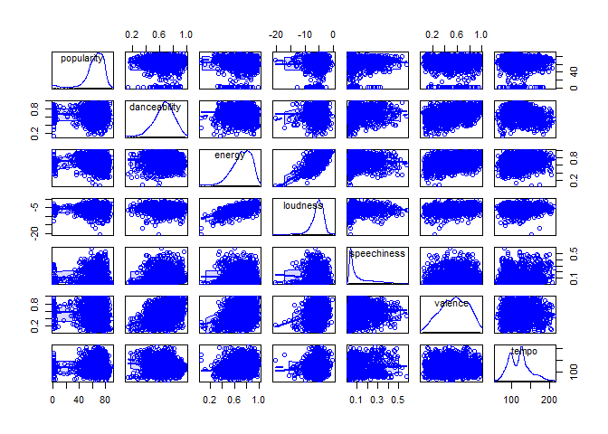

```r
scatterplotMatrix(formula = ~ popularity + danceability + energy + loudness + speechiness + valence+tempo, transform=TRUE, by.group= TRUE, data = s1)
```

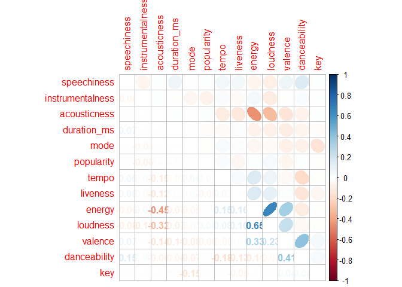

```r
corrplot.mixed(cor(s1), upper= "ellipse", tl.pos = "lt", order="AOE")
```

```r
powerTransform(s1$popularity)
```

```
## Estimated transformation parameter
## s1$popularity
##      2.065506
```

```r
powerTransform(s1$speechiness)
```

```
## Estimated transformation parameter
## s1$speechiness
##     -0.4937706
```

```r
powerTransform(s1$energy)
```

```
## Estimated transformation parameter
## s1$energy
##  1.916976
```

```r
powerTransform(s1$danceability)
```

```
## Estimated transformation parameter
## s1$danceability
##         1.58045
```

```r
powerTransform(s1$tempo)
```

```
## Estimated transformation parameter
##    s1$tempo
## -0.05345814
```

```r
powerTransform(s1$valence)  ## valence is already normally distributed, therefore we obtain                                  0.987, which is near 1
```

```
## Estimated transformation parameter
## s1$valence
##  0.9876734
```

Once we have estimated the *lambda* values, we change all variables’ values with the “bcPower” function, which is a function that transform a column’s value with the Box-Cox transformation, given a certain value of the constant (which we have obtained with the code above)

```r
lambda_popularity <- coef(powerTransform(s1$popularity))
bcPower(s1$popularity, lambda_popularity)

lambda_speechiness <- coef(powerTransform(s1$speechiness))
bcPower(s1$speechiness, lambda_speechiness)

lambda_energy <- coef(powerTransform(s1$energy))
bcPower(s1$energy, lambda_energy)

lambda_danceability <- coef(powerTransform(s1$danceability))
bcPower(s1$danceability, lambda_danceability)

lambda_tempo <- coef(powerTransform(s1$tempo))
bcPower(s1$tempo, lambda_tempo)
```

Since the variable loudness has negative values, we need to use the second version of the Box-Cox transformation:

```r
summary(s1$loudness)  #since loudness has a min value of -20.5, we just need to add 21
```

```
##    Min. 1st Qu.  Median    Mean 3rd Qu.    Max.
## -20.514  -6.478  -5.280  -5.506  -4.162  -0.276
```

```r
S1 <- s1 %>% mutate(loudness_2.0 = loudness + 21)
```

```r
lambda_loudness <- coef(powerTransform(S1$loudness_2.0))
bcPower(S1$loudness_2.0, lambda_loudness)
```

Now, we can create a table where the transformed values are added, in order to check if we respect the normality assumption of the linear model:

```r
s2 <- s1 %>% mutate(popularity_trfm = bcPower(s1$popularity,lambda_popularity),
                    speechiness_trfm = bcPower(s1$speechiness, lambda_speechiness),
                    danceability_trfm = bcPower(s1$danceability, lambda_danceability),
                    energy_trfm = bcPower(s1$energy, lambda_energy),
                    tempo_trfm = bcPower(s1$tempo, lambda_tempo),
                    loudness_trfm = bcPower(S1$loudness_2.0, lambda_loudness)) %>% select(1, 5, 7, 9, 10,12, 14:19)

kable(s2, caption = " Table 1: Transformed values for normal distribution")%>%
   kableExtra::scroll_box(width = "780px", height = "600px")
```

Table 1: Transformed values for normal distribution

[output not shown]

[output cut: 1763 more lines]

Let’s now check the normal distribution and the correlations among variables, running again the “scatterplotMatrix()” and “corrplot.mixed()” functions

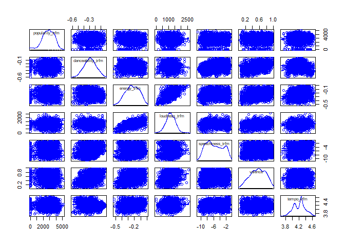

```r
scatterplotMatrix(formula = ~ popularity_trfm + danceability_trfm + energy_trfm + loudness_trfm + speechiness_trfm + valence+ tempo_trfm, transform=TRUE, by.group= TRUE, data = s2)
```

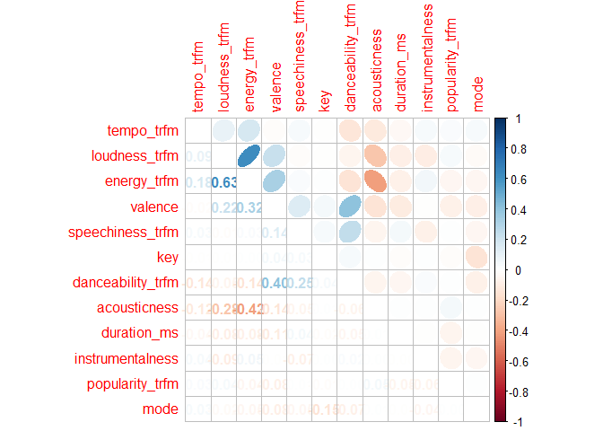

```r
corrplot.mixed(cor(s2), upper= "ellipse", tl.pos = "lt", order="AOE")
```

# 2.2 Multi-linear regression

Firstly, let’s try to build a lm model with all the variables elaborated before that could be of any help in predicting the popularity of a song.

```r
m1 <- lm(popularity_trfm ~ energy_trfm+loudness_trfm+valence+danceability_trfm+speechiness_trfm, data=s2)
summary(m1)
```

```
##
## Call:
## lm(formula = popularity_trfm ~ energy_trfm + loudness_trfm +
##     valence + danceability_trfm + speechiness_trfm, data = s2)
##
## Residuals:
##      Min       1Q   Median       3Q      Max
## -3026.16  -592.02    70.73   720.59  2233.56
##
## Coefficients:
##                    Estimate Std. Error t value Pr(>|t|)
## (Intercept)       2614.7533   208.5698  12.537  < 2e-16 ***
## energy_trfm       -678.6511   299.1625  -2.269 0.023417 *
## loudness_trfm        0.2809     0.0798   3.520 0.000443 ***
## valence           -415.1522   126.6481  -3.278 0.001066 **
## danceability_trfm  286.5140   250.1184   1.146 0.252150
## speechiness_trfm     5.9153     9.1588   0.646 0.518452
## ---
## Signif. codes:  0 '***' 0.001 '**' 0.01 '*' 0.05 '.' 0.1 ' ' 1
##
## Residual standard error: 983.1 on 1787 degrees of freedom
## Multiple R-squared:  0.01444,    Adjusted R-squared:  0.01168
## F-statistic: 5.237 on 5 and 1787 DF,  p-value: 8.864e-05
```

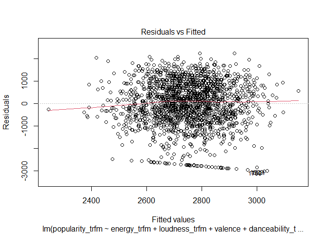

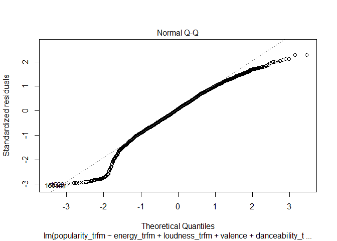

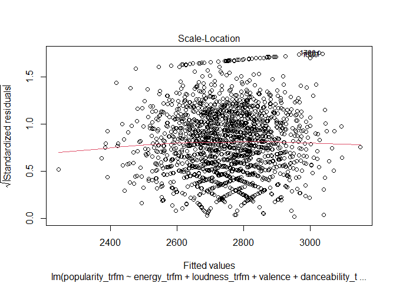

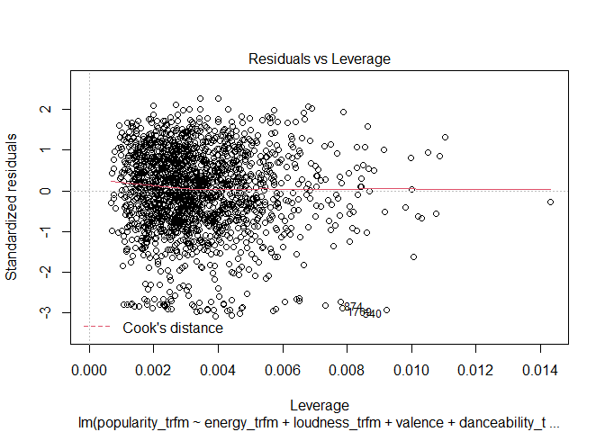

```r
plot(m1)
```

Let’s try to exclude those variables and check for the changes in our model.

```r
m1.2 <- lm(popularity_trfm ~ energy_trfm+loudness_trfm+valence, data=s2)
summary(m1.2)
```

```
##
## Call:
## lm(formula = popularity_trfm ~ energy_trfm + loudness_trfm +
##     valence, data = s2)
##
## Residuals:
##      Min       1Q   Median       3Q      Max
## -3019.91  -584.02    77.43   724.49  2211.21
##
## Coefficients:
##                 Estimate Std. Error t value Pr(>|t|)
## (Intercept)   2427.88814  162.21846  14.967  < 2e-16 ***
## energy_trfm   -773.98298  286.75997  -2.699 0.007019 **
## loudness_trfm    0.28274    0.07963   3.551 0.000394 ***
## valence       -334.08509  111.39247  -2.999 0.002745 **
## ---
## Signif. codes:  0 '***' 0.001 '**' 0.01 '*' 0.05 '.' 0.1 ' ' 1
##
## Residual standard error: 983.2 on 1789 degrees of freedom
## Multiple R-squared:  0.01326,    Adjusted R-squared:  0.0116
## F-statistic: 8.012 on 3 and 1789 DF,  p-value: 2.644e-05
```

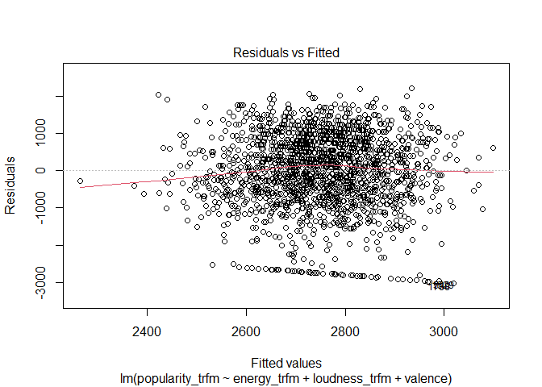

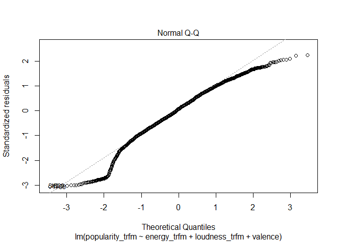

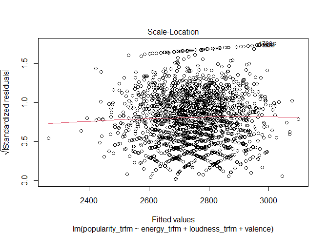

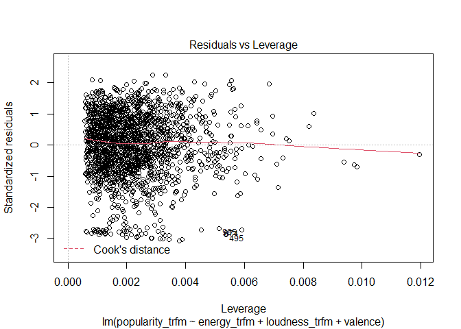

```r
plot(m1.2)
```

Now all the variables considered are statistically significant. However, the model is a bit weaker than the one above. It seems that nothing really relevant can be obtained from such a model. This final results had to be expected since it is implausible to predict the popularity of all songs in general, without dividing them into genres. In fact, loudness could make a rock song popular, but maybe it could have the opposite effect on a pop one.

## 3 Exploration of genres

# 3.1 Preliminary classification

Let’s use the table() function to see each unique genre and how many songs it has

```r
table(sg_cleaned$genre)
```

```
##
##                               country                      Dance/Electronic
##                                     8                                    38
##                        easy listening                    Folk/Acoustic, pop
##                                     1                                     2
##              Folk/Acoustic, rock, pop                               hip hop
##                                     1                                   113
##                      hip hop, country             hip hop, Dance/Electronic
##                                     1                                    14
##      hip hop, latin, Dance/Electronic                          hip hop, pop
##                                     1                                   260
##                 hip hop, pop, country        hip hop, pop, Dance/Electronic
##                                     1                                    70
##                   hip hop, pop, latin                     hip hop, pop, R&B
##                                    14                                   223
##   hip hop, pop, R&B, Dance/Electronic              hip hop, pop, R&B, latin
##                                     3                                     2
##                    hip hop, pop, rock                          hip hop, R&B
##                                     9                                     3
##                    hip hop, rock, pop                                 latin
##                                     1                                    14
##                                 metal                                   pop
##                                     9                                   383
##                          pop, country                 pop, Dance/Electronic
##                                     8                                   184
## pop, easy listening, Dance/Electronic             pop, easy listening, jazz
##                                     1                                     2
##                    pop, Folk/Acoustic                            pop, latin
##                                     7                                    26
##                              pop, R&B            pop, R&B, Dance/Electronic
##                                   163                                     6
##              pop, R&B, easy listening                             pop, rock
##                                     1                                    26
##           pop, rock, Dance/Electronic              pop, rock, Folk/Acoustic
##                                     9                                     2
##                      pop, rock, metal                                   R&B
##                                    14                                    13
##                                  rock                           rock, blues
##                                    55                                     2
##                    rock, blues, latin                       rock, classical
##                                     2                                     1
##                rock, Dance/Electronic                  rock, easy listening
##                                     1                                     1
##   rock, Folk/Acoustic, easy listening              rock, Folk/Acoustic, pop
##                                     1                                     1
##                           rock, metal                             rock, pop
##                                    36                                    38
##           rock, pop, Dance/Electronic                      rock, pop, metal
##                                     7                                     4
##    rock, pop, metal, Dance/Electronic         rock, R&B, Folk/Acoustic, pop
##                                     1                                     1
##      World/Traditional, Folk/Acoustic            World/Traditional, hip hop
##                                     1                                     2
##                World/Traditional, pop World/Traditional, pop, Folk/Acoustic
##                                     1                                     2
##               World/Traditional, rock          World/Traditional, rock, pop
##                                     2                                     1
```

Since the column ‘genre’ has all the possible ‘classification genre’ of a song, let’s assume that the first mentioned is the most relevant one, namely that a ‘*hip-hop, pop, latin*’ song is first of all an hip-hop song, with certain elements of the remaining two.

Let’s split the column genre into first, second and third genre to have a clearer vision:

```r
w <- s2 %>% mutate(genre = sg_cleaned$genre) %>%
            separate(genre, c("main genre", "secondary genre", "tertiary genre"), ",")

## let's also have a glance at the results obtained

table(w$`main genre`)
```

```
##
##           country  Dance/Electronic    easy listening     Folk/Acoustic
##                 8                38                 1                 3
##           hip hop             latin             metal               pop
##               715                14                 9               832
##               R&B              rock World/Traditional
##                13               151                 9
```

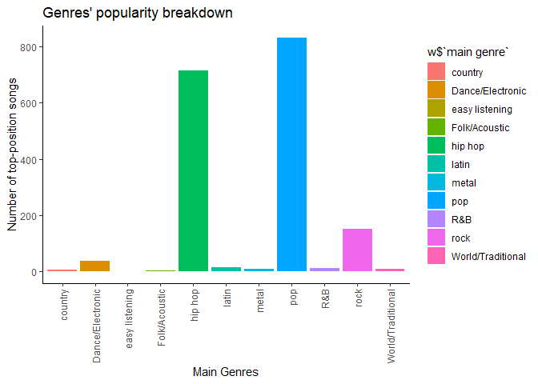

```r
ggplot(data=w)+ aes(w$`main genre`)+
  geom_bar(mapping=aes(fill=w$`main genre`))+
  theme_classic()+
  labs(x="Main Genres", y="Number of top-position songs", title="Genres' popularity breakdown")+
  theme(axis.text.x = element_text(angle = 90, vjust = 0.5, hjust=1))
```

As we can see, the vast majority of popular songs are either hip-hop or pop ones. Rock seems to be quite popular but below the 200 entries. This means that we have enough entries for a significant model only for these 3 genres. Thus, we need to exclude the others from our analysis.

# 3.2 Predicting pop an hip-hop songs

Let’s now try to build a model for the two most popular genres. Firstly, we consider pop:

```r
genre_1 <- w %>% filter(`main genre` == "pop")%>% as.data.frame()

M2 <- lm(popularity_trfm ~  energy_trfm+ valence +tempo_trfm+ instrumentalness+ speechiness_trfm, data=genre_1)
summary(M2)
```

```
##
## Call:
## lm(formula = popularity_trfm ~ energy_trfm + valence + tempo_trfm +
##     instrumentalness + speechiness_trfm, data = genre_1)
##
## Residuals:
##      Min       1Q   Median       3Q      Max
## -2910.75  -593.03    63.34   738.52  2230.51
##
## Coefficients:
##                  Estimate Std. Error t value Pr(>|t|)
## (Intercept)       2309.25     974.25   2.370   0.0180 *
## energy_trfm       -892.30     359.51  -2.482   0.0133 *
## valence            -68.73     168.74  -0.407   0.6839
## tempo_trfm          66.79     218.13   0.306   0.7595
## instrumentalness  -104.29     389.24  -0.268   0.7888
## speechiness_trfm    14.13      15.27   0.925   0.3552
## ---
## Signif. codes:  0 '***' 0.001 '**' 0.01 '*' 0.05 '.' 0.1 ' ' 1
##
## Residual standard error: 998.4 on 826 degrees of freedom
## Multiple R-squared:  0.01053,    Adjusted R-squared:  0.004544
## F-statistic: 1.759 on 5 and 826 DF,  p-value: 0.1189
```

As we can see, only teh energy variable has an acceptabe p-value, while all other variables haven’t. Moreover, even ignoring the p-value issue, we are left with a weak model (R squared = 1%)

Let’s now try with hip-hop:

```r
genre_2 <- w %>% filter(`main genre` == "hip hop")%>% as.data.frame()

M3 <- lm(popularity_trfm ~ energy_trfm +tempo_trfm+ instrumentalness+ speechiness_trfm, data=genre_2)
summary(M3)
```

```
##
## Call:
## lm(formula = popularity_trfm ~ energy_trfm + tempo_trfm + instrumentalness +
##     speechiness_trfm, data = genre_2)
##
## Residuals:
##      Min       1Q   Median       3Q      Max
## -2968.11  -577.09    75.18   671.00  2095.90
##
## Coefficients:
##                  Estimate Std. Error t value Pr(>|t|)
## (Intercept)        858.42     823.75   1.042   0.2977
## energy_trfm         30.44     350.28   0.087   0.9308
## tempo_trfm         451.27     192.97   2.339   0.0196 *
## instrumentalness   471.19     824.59   0.571   0.5679
## speechiness_trfm   -15.21      14.50  -1.049   0.2944
## ---
## Signif. codes:  0 '***' 0.001 '**' 0.01 '*' 0.05 '.' 0.1 ' ' 1
##
## Residual standard error: 943.3 on 710 degrees of freedom
## Multiple R-squared:  0.01005,    Adjusted R-squared:  0.004476
## F-statistic: 1.803 on 4 and 710 DF,  p-value: 0.1265
```

Since here we have the same problem as before, let’s try to exclude all variables except tempo:

```r
M3.1 <- lm(popularity_trfm ~ tempo_trfm, data=genre_2)
summary(M3.1)
```

```
##
## Call:
## lm(formula = popularity_trfm ~ tempo_trfm, data = genre_2)
##
## Residuals:
##      Min       1Q   Median       3Q      Max
## -2967.73  -571.50    78.44   685.90  2107.37
##
## Coefficients:
##             Estimate Std. Error t value Pr(>|t|)
## (Intercept)    897.3      804.4   1.115   0.2650
## tempo_trfm     456.5      191.9   2.379   0.0176 *
## ---
## Signif. codes:  0 '***' 0.001 '**' 0.01 '*' 0.05 '.' 0.1 ' ' 1
##
## Residual standard error: 942.4 on 713 degrees of freedom
## Multiple R-squared:  0.007875,   Adjusted R-squared:  0.006483
## F-statistic: 5.659 on 1 and 713 DF,  p-value: 0.01763
```

Tempo seems to have a weak correlation with popularity and the model itself is not strong since it has a very low R-squared value.

# 3.3 Predicting rock songs

For our last attempt, let’s try to find correlations in rock songs:

```r
genre_3 <- w %>% filter(`main genre` == "rock")%>% as.data.frame()

M6 <- lm(popularity_trfm ~ energy_trfm +instrumentalness + loudness_trfm+tempo_trfm+speechiness_trfm, data=genre_3)
summary(M6)
```

```
##
## Call:
## lm(formula = popularity_trfm ~ energy_trfm + instrumentalness +
##     loudness_trfm + tempo_trfm + speechiness_trfm, data = genre_3)
##
## Residuals:
##     Min      1Q  Median      3Q     Max
## -2905.7  -563.6   135.1   738.5  2245.8
##
## Coefficients:
##                    Estimate Std. Error t value Pr(>|t|)
## (Intercept)       3289.6526  2132.3824   1.543 0.125080
## energy_trfm        144.9334   990.6105   0.146 0.883882
## instrumentalness -2821.7943   716.7534  -3.937 0.000128 ***
## loudness_trfm       -0.2195     0.3224  -0.681 0.497157
## tempo_trfm         -85.5189   474.3597  -0.180 0.857182
## speechiness_trfm   -76.7176    41.5820  -1.845 0.067082 .
## ---
## Signif. codes:  0 '***' 0.001 '**' 0.01 '*' 0.05 '.' 0.1 ' ' 1
##
## Residual standard error: 981.7 on 145 degrees of freedom
## Multiple R-squared:  0.1143, Adjusted R-squared:  0.08372
## F-statistic: 3.741 on 5 and 145 DF,  p-value: 0.003245
```

We need to exclude all variables with an unacceptable p-value (we keep speechiness_trfm because it has a p-value near 0,5):

```r
M6.1 <- lm(popularity_trfm ~ instrumentalness+speechiness_trfm, data=genre_3)
summary(M6.1)
```

```
##
## Call:
## lm(formula = popularity_trfm ~ instrumentalness + speechiness_trfm,
##     data = genre_3)
##
## Residuals:
##     Min      1Q  Median      3Q     Max
## -2914.1  -538.4   109.2   743.6  2126.2
##
## Coefficients:
##                  Estimate Std. Error t value Pr(>|t|)
## (Intercept)       2579.13     288.40   8.943 1.42e-15 ***
## instrumentalness -2689.79     688.55  -3.906 0.000142 ***
## speechiness_trfm   -82.65      39.39  -2.098 0.037579 *
## ---
## Signif. codes:  0 '***' 0.001 '**' 0.01 '*' 0.05 '.' 0.1 ' ' 1
##
## Residual standard error: 973.9 on 148 degrees of freedom
## Multiple R-squared:  0.1102, Adjusted R-squared:  0.09818
## F-statistic: 9.165 on 2 and 148 DF,  p-value: 0.0001768
```

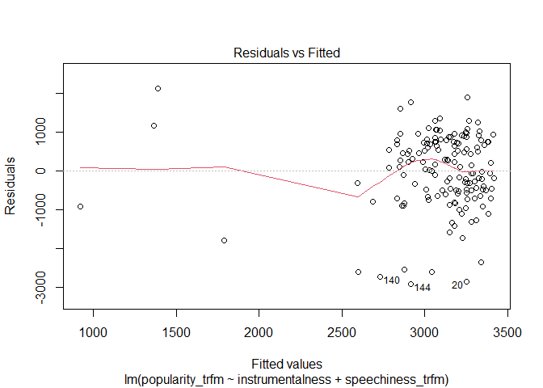

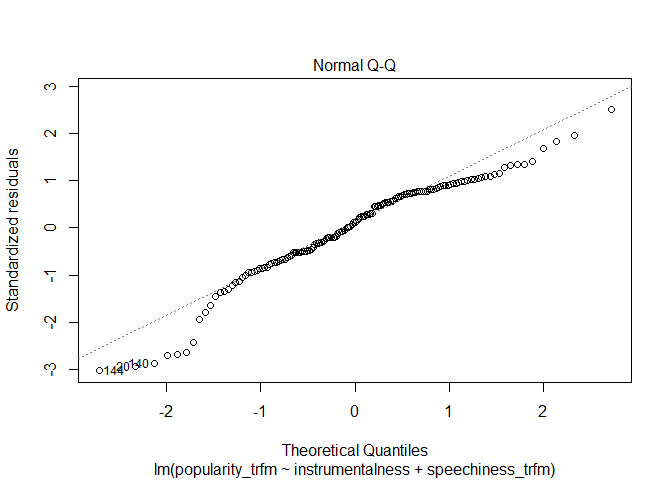

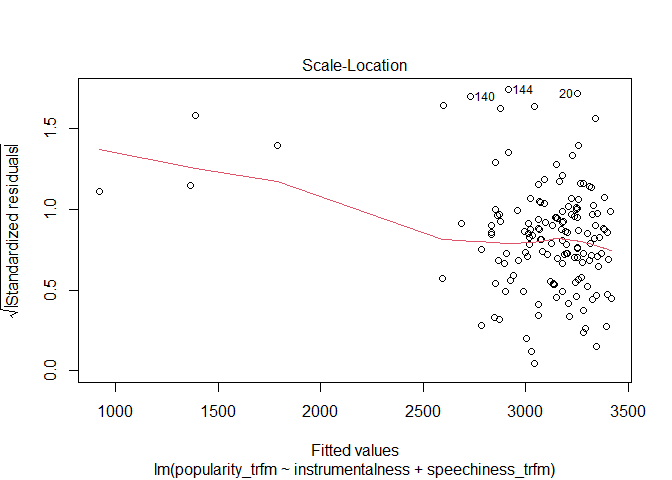

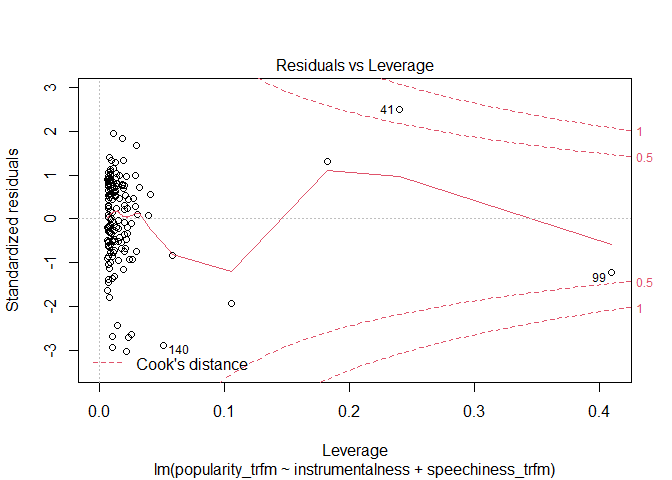

```r
plot(M6.1)
```

The model seems to be the best one so far, but we need to eliminate outliers:

```r
genre_3.cleaned <- genre_3[-c(41, 43),]
M6.1_cleaned <- lm(popularity_trfm ~ instrumentalness+speechiness_trfm, data=genre_3.cleaned)
summary(M6.1_cleaned)
```

```
##
## Call:
## lm(formula = popularity_trfm ~ instrumentalness + speechiness_trfm,
##     data = genre_3.cleaned)
##
## Residuals:
##     Min      1Q  Median      3Q     Max
## -2900.3  -530.0   109.5   708.1  1999.9
##
## Coefficients:
##                  Estimate Std. Error t value Pr(>|t|)
## (Intercept)       2529.60     282.96   8.940 1.58e-15 ***
## instrumentalness -4463.37     863.25  -5.170 7.56e-07 ***
## speechiness_trfm   -91.47      38.71  -2.363   0.0194 *
## ---
## Signif. codes:  0 '***' 0.001 '**' 0.01 '*' 0.05 '.' 0.1 ' ' 1
##
## Residual standard error: 946 on 146 degrees of freedom
## Multiple R-squared:  0.1691, Adjusted R-squared:  0.1577
## F-statistic: 14.85 on 2 and 146 DF,  p-value: 1.343e-06
```

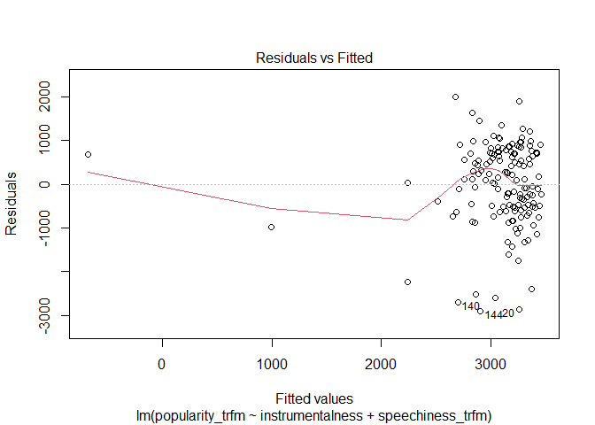

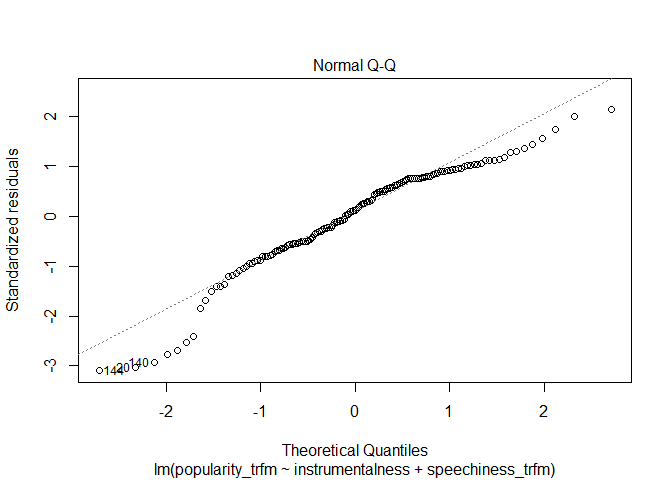

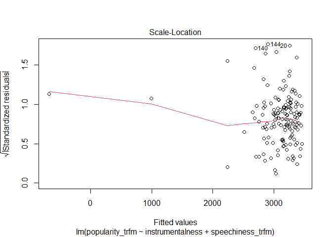

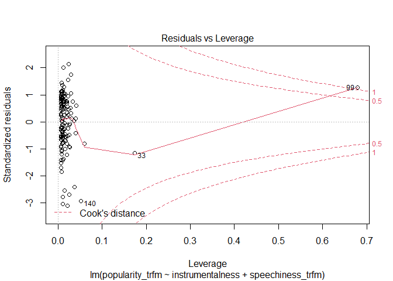

```r
plot(M6.1_cleaned)  ##seems we have to exclude another observation
```

```r
genre_3.cleaned.v2 <- genre_3[-c(41, 43, 99),]
M6.1_cleaned.v2 <- lm(popularity_trfm ~ instrumentalness+speechiness_trfm, data=genre_3.cleaned.v2)
summary(M6.1_cleaned.v2)
```

```
##
## Call:
## lm(formula = popularity_trfm ~ instrumentalness + speechiness_trfm,
##     data = genre_3.cleaned.v2)
##
## Residuals:
##     Min      1Q  Median      3Q     Max
## -2921.3  -532.8   123.6   698.9  2220.5
##
## Coefficients:
##                  Estimate Std. Error t value Pr(>|t|)
## (Intercept)       2556.46     283.13   9.029 9.77e-16 ***
## instrumentalness -6037.42    1503.46  -4.016 9.48e-05 ***
## speechiness_trfm   -90.02      38.64  -2.330   0.0212 *
## ---
## Signif. codes:  0 '***' 0.001 '**' 0.01 '*' 0.05 '.' 0.1 ' ' 1
##
## Residual standard error: 944 on 145 degrees of freedom
## Multiple R-squared:  0.1249, Adjusted R-squared:  0.1128
## F-statistic: 10.35 on 2 and 145 DF,  p-value: 6.288e-05
```

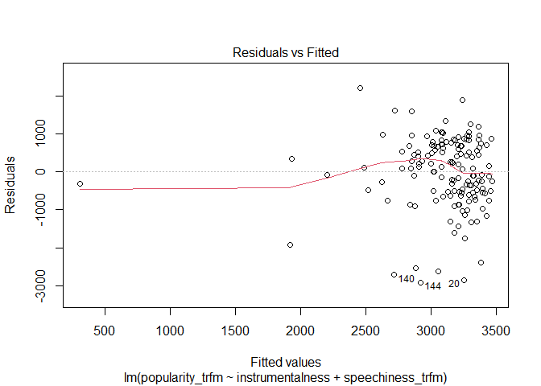

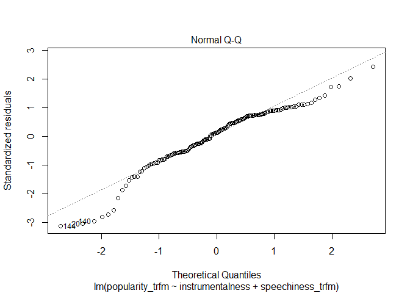

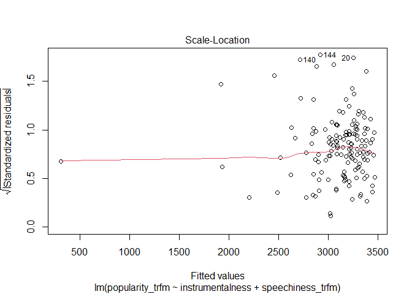

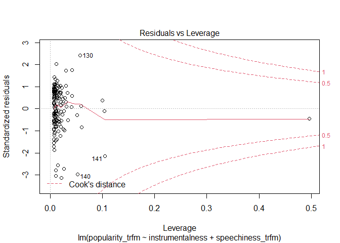

```r
plot(M6.1_cleaned.v2)
```

```r
cor(genre_3.cleaned.v2$popularity_trfm, genre_3.cleaned.v2$instrumentalness, method = 'pearson')
```

```
## [1] -0.3035874
```

```r
cor(genre_3.cleaned.v2$popularity_trfm, genre_3.cleaned.v2$speechiness_trfm, method = 'pearson')
```

```
## [1] -0.1661311
```

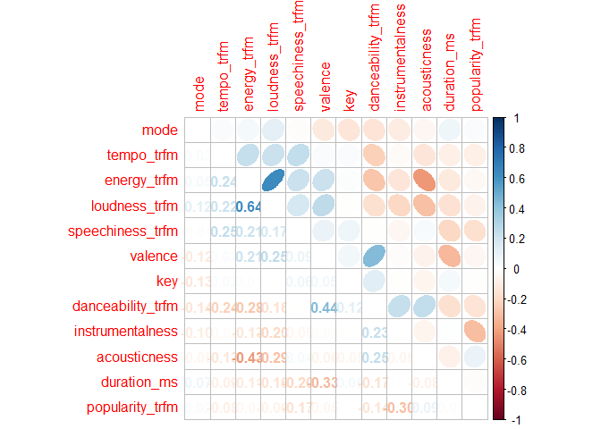

```r
corrplot.mixed(cor(genre_3.cleaned.v2[1:12]), upper= "ellipse", tl.pos = "lt", order="AOE")
```

Both variables have a weak negative correlation with popularity of rock songs. However, our correlation map is, in general, more explicative than the initial one. The last thing we need to check is if our model actually respect the two main assumptions of linear regression: homoscedasticity and normal distribution

```r
bptest(M6.1_cleaned.v2)  ## there is homoscedasticity/constant variance
```

```
##
##  studentized Breusch-Pagan test
##
## data:  M6.1_cleaned.v2
## BP = 1.9361, df = 2, p-value = 0.3798
```

```r
shapiro.test(genre_3.cleaned.v2$instrumentalness)
```

```
##
##  Shapiro-Wilk normality test
##
## data:  genre_3.cleaned.v2$instrumentalness
## W = 0.28591, p-value < 2.2e-16
```

```r
shapiro.test(genre_3.cleaned.v2$speechiness_trfm) #the hypothesis of normal distribution if the independent variables is violated
```

```
##
##  Shapiro-Wilk normality test
##
## data:  genre_3.cleaned.v2$speechiness_trfm
## W = 0.9559, p-value = 0.0001173
```

## Conclusions

Our analysis started with all songs in general and then we have soon realized that a partition by genre was necessary, since every variable is expected to play a different role in different genres. However, since the vast majority of popular songs were either pop songs or hip-hop ones, we had to restrict our analysis to genres with enough entries, namely hip-hop, pop and rock. Regarding the first two, no significant model was found, since most of the variables considered had an unacceptable p-value. The only model acceptable was the last one, for which both *instrumentalness* and *speechiness* have a weak negative correlation with the popularity of rock songs. However, the model itself has not passed the Shapiro-Wilk test, therefore is not strictly speaking reliable

In conclusion, no significant correlation or valid model were found.